# DS4IR - Instruções do curso

Davi Moreira e Rafael Magalhães

20 de julho de 2020

## Introdução

Este é um documento adicional ao Programa do Curso. Seu objetivo é detalhar alguns aspectos que contribuem para o desenvolvimento das aulas.

## Dinâmica da aula

De segunda a sexta, a aula tem início às 18h e termina 23h. Sendo um curso intensivo e remoto, para torná-lo eficiente e agradável vamos adotar a seguinte dinâmica a partir do segundo encontro:

### Parte I (18h-18h30): Q&A

Tempo dedicado a dúvidas referentes ao encontro anterior e ao curso. Nesses 30 minutos os alunos estão convidados a tirar quaisquer dúvidas do curso com os professores.

### Parte II (18h30): Resolução assignment

Resolução conjunta do *assignment* do encontro anterior. Os professores apresentarão passo-a-passo formas de resolução do exercício cobrado.

### Parte III: Exposição de conteúdo

Exposição do conteúdo do encontro. Os professores farão a exposição do conteúdo de modo que os alunos possam acompanhá-la sistemáticamente onde quer que estejam. Ao longo da exposição, os alunos serão convidados a realizar de 2 a 3 exercícios em grupo.

- **Definição dos grupos**: os grupos terão de 3 a 6 integrantes aleatoriamente alocados de acordo com a ferramenta *breakout rooms* do aplicatovo Zoom.
- **Tempo para os exercícios**: cada exercício terá de 10 a 20 minutos para sua conclusão em grupo. Nesse tempo, estimulamos a interação entre os estudantes. A resolução conjunta será realizada assim que o tempo se esgotar.

### Parte IV: Intervalo

Intervalo de 30 minutos, com início e retorno definidos pelos professores em aula.

### Parte V (até 23h): Assignment

Tempo dedicado a apresentação do *assignment* e resolução dos alunos em grupo.

## Sobre a plataforma de aula: Zoom

Nesse curso vamos usar a plataforma Zoom. Para uma boa experiência, temos algumas recomendações:

- **Câmera**: é recomendável manter sua câmera ligada. O contato visual estimula interação e fará diferença ao longo do curso.
- **Microfone**: durante as exposições os professores deixarão mudos os microfones dos alunos, sendo recomendável que o mantenham desse modo. Durante as seções em grupos, fique à vontade para ativá-lo e interagir com os colegas. Isso também vale para a Parte I da aula.
- **Chat**: Os professores não vão acompanhar o *Chat*. Ele pode ser usado como fórum para livre interação da turma.

### Observações importantes

- Por segurança, todos os encontros serão gravados pelos professores. Os alunos **não** têm autorização para gravar.
- Qualquer tipo de discurso de ódio ou preconceituoso não será tolerado.
- **Lembre-se**: tudo que é feito em ambiente virtual é gravado, registrado e pode ser posteriormente resgatado/consultado. Por isso, contamos com a ética e a educação de vocês. Temos certeza de que teremos uma ótima experiência.

## Sobre o `RStudioCloud`

Para otimizar o uso dos recursos mais avançados em ciência de dados, faremos uso da plataforma `RStudio Cloud`. Vocês já receberam o convite para integrar o ambiente de trabalho do curso (nossa sala de aula). Nele, terão acesso a um projeto por aula.

### Organização de cada aula/projeto

- Ao acessar sua área de trabalho no `RStudio Cloud`, você encontrará pastas com o conteúdo de cada aula, disponibilizado na data do encontro.

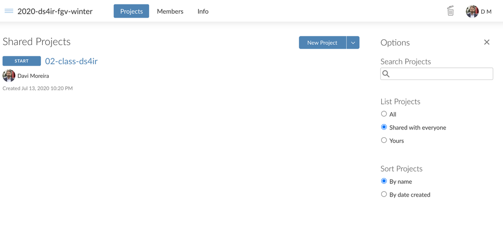

- Iniciando cada aula você será direcionado ao ambiente do `RStudio`. Este ambiente virtual é idêntico ao ambiente local, mas está configurado para nosso curso. É nesse ambiente que encontrará o material de aula e deverá realizar as tarefas necessárias.

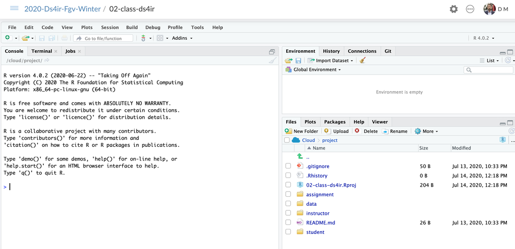

### Observações importantes

- Ao iniciar cada aula, uma cópia do projeto é feita para o sua área de trabalho. Porém, os professores têm acesso a ele.
- Desenvolva **todas** as tarefas do curso usando a plataforma. Ela garantirá que seu aprendizado seja flúido e contínuo.
- Ficaremos felizes em tirar dúvidas sobre o uso do `RStudio` em seu equipamento próprio, mas não encorajamos o seu uso para o curso.

## Material de aula

As aulas estão organizadas em projetos que contam sempre com a mesma estrutura básica de pastas no seu painel de arquivos:

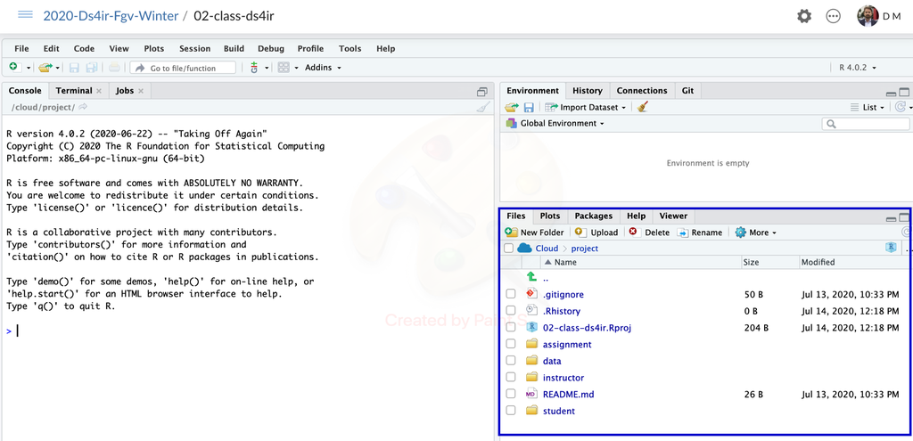

Nas aulas, vamos focar em duas extensões de arquivos `.R` e `.Rmd`. Suas características e diferenças ficarão mais claras com a prática do curso.

### `student`

Nessa pasta que você encontra o seu material de aula. O curso foi formulado para que você use esse material durante a exposição do conteúdo.

### `assignment`

Nessa pasta que você encontra o arquivo com as instruções da tarefa da aula. É recomendável que você use esse mesmo arquivo para desenvolver a tarefa.

### `data`

Nessa pasta estarão todas as bases de dados necessárias para a exposição do conteúdo e para o desenvolvimento do *assignment* da aula.

### `instructor`

Nessa pasta estarão todos os arquivos finais e fontes primárias utilizadas pelos professores para o desenvolvimento do conteúdo da aula. Recomendamos que **não** usem essa pasta durante as aulas. Disponibilizar os códigos originais é uma gentileza nossa a vocês.

## Presença

A plataforma Zoom automaticamente registra sua entrada e saída da sala. Sua presença no curso será computada de acordo com esse registro. Por isso, diante de uma eventual instabilidade de conexão você não será prejudicado e poderá acessar a sala quando a conexão se estabilizar.

## Avaliação

A avaliação seguirá o disposto no programa segundo as regras a seguir:

### Entrega dos *assignments*

- É recomendável que as tarefas sejam concluídas no tempo de aula ou até o início da aula seguinte.
- Os professores têm acesso às pastas de aulas de cada um de vocês. Após a conclusão do curso os professores vão checar o trabalho desenvolvido e contido na pasta *assignment* de cada aula.